# velo.com_assignment

Anusha Dsilva

10/17/2021

## Load data and packages

```r
library(tidyverse)

v <- read_csv("velo.csv")
glimpse(v)
```

```
## Rows: 44,059
## Columns: 7
## $ customer_id     <dbl> 51663, 57870, 2986, 29925, 95246, 68293, 62555, 45404,~
## $ country         <chr> "MEX", "USA", "USA", "USA", "ESP", "USA", "GBR", "TUR"~
## $ gender          <chr> "F", "M", "F", "F", "M", "M", "F", "M", "M", "F", "F",~
## $ spent           <dbl> 967.78, 2633.68, 3917.25, 3174.38, 223.84, 211.39, 493~
## $ device          <chr> "computer", "computer", "computer", "computer", "mobil~
## $ checkout_system <chr> "new", "new", "old", "old", "new", "new", "new", "new"~
## $ purchases       <dbl> 5, 2, 6, 3, 3, 4, 4, 7, 2, 2, 3, 10, 8, 3, 2, 1, 4, 2,~
```

## Questions

Lightly comment your code and use pipes for readability.

Comment briefly on each of the questions, as directed. Only the the final question requires a lengthier response.

### Q1

Plot the distribution of `spent` by `checkout_system`. Below you will use a t-test to compare these distributions statistically. However, a t-test assumes normally distributed data. Is that assumption valid in this case? Why or why not?

Note:

1. You could compare the two distributions using histograms but a density plot works better. (A boxplot is also an option.)
2. Make sure to include a plot title.

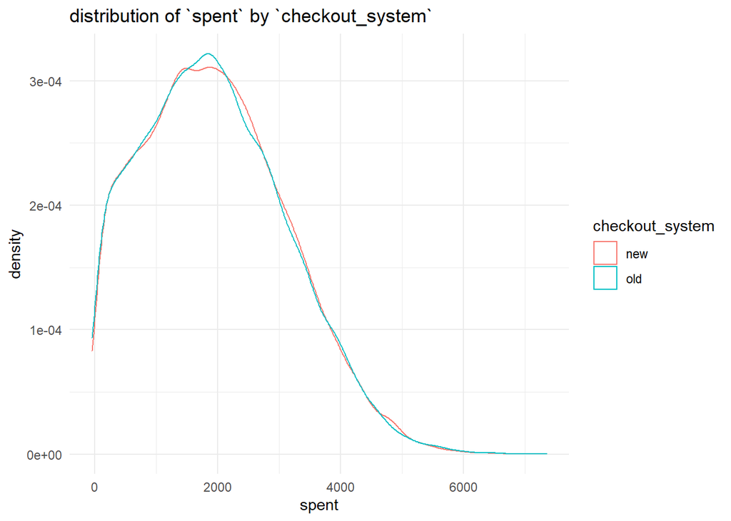

```r
ggplot(v, aes(x = spent, col = checkout_system))+
  geom_density() +
  theme_minimal() +
  labs(title = "distribution of `spent` by `checkout_system`")
```

Create a summary table of `spent` by `checkout_system` with the following statistics:

- n
- mean
- median
- standard deviation
- total
- the lower and upper bound of a 95% z-confidence interval for the mean.

Your table should have 2 rows and 8 columns.

```r
v %>%
  group_by(checkout_system) %>%
  summarize(n = n(),
            mean = mean(spent),
            sd = sd(spent),
            median = median(spent),
            se = (sd/sqrt(n)),
            lowerCI = (mean - 1.96 * se) %>%  round(2),
            upperCI = (mean + 1.96 * se)  %>%  round(2))
```

```
## # A tibble: 2 x 8
##   checkout_system     n  mean    sd median    se lowerCI upperCI
##   <chr>           <int> <dbl> <dbl>  <dbl> <dbl>   <dbl>   <dbl>
## 1 new             22874 1971. 1166.  1889.  7.71   1956.   1986.
## 2 old             21185 1956. 1169.  1868.  8.03   1941.   1972.
```

### Q3

Is average spending significantly higher in the treatment group? (The treatment group consists in the customers using the new checkout system.) Answer this question using a 2 sample, 2-tailed t-test with alpha set at .05. (Note that these are the default settings for the `t.test()` function when vectors are supplied for the x and y arguments.)

```r
?t.test
t.test(x = filter(v, checkout_system == "new")$spent,
       y = filter(v, checkout_system == "old")$spent,
       alternative = c("two.sided"))
```

```
##
##  Welch Two Sample t-test
##
## data:  filter(v, checkout_system == "new")$spent and filter(v, checkout_system == "old")$spent
## t = 1.3342, df = 43780, p-value = 0.1822
## alternative hypothesis: true difference in means is not equal to 0
## 95 percent confidence interval:
##  -6.968196 36.677818
## sample estimates:
## mean of x mean of y
##  1971.245  1956.390
```

> Answer: yes , the average spending is not significantly higher in treatment group.Here P-value 0.1822 is greater than the aplha set value 0.05.Hence its not significant.

### Q4

Create another summary table of `spent` by `checkout_system` and `device`. Include these same statistics:

- n
- mean
- median
- standard deviation
- the lower and upper bound of a 95% confidence interval for the mean.

```r
v %>%
  group_by(checkout_system,device) %>%
  summarize(n = n(),
            mean = mean(spent),
            sd = sd(spent),
            median = median(spent),
            se = (sd/sqrt(n)),
            lowerCI = (mean - 1.96 * se) %>%  round(2),
            upperCI = (mean + 1.96 * se)  %>%  round(2))
```

```
## # A tibble: 4 x 9
## # Groups:   checkout_system [2]
##   checkout_system device       n  mean    sd median    se lowerCI upperCI
##   <chr>           <chr>    <int> <dbl> <dbl>  <dbl> <dbl>   <dbl>   <dbl>
## 1 new             computer 11379 1976. 1159.  1901.  10.9   1954.   1997.
## 2 new             mobile   11495 1967. 1173.  1880.  10.9   1945.   1988.
## 3 old             computer 11522 1977. 1169.  1895.  10.9   1956.   1998.
## 4 old             mobile    9663 1932. 1169.  1840.  11.9   1908.   1955.
```

The table should have 4 rows and 8 columns.

Based on this information (as well as Sarah’s observation, noted in the case description, that the glitch in the checkout system seemed more prevalent for mobile users), an additional statistical comparison of new and old among just mobile users seems warranted. Make that comparison using a 2 sample, 2-tailed t-test with alpha set at .05. Report your results.

Note that a t-test can only compare two groups. Therefore, you will need to subset the data before making the comparison.

```r
?t.test
t.test(x = filter(v, checkout_system == "new",device =='mobile')$spent,
       y = filter(v, checkout_system == "old",device =='mobile')$spent,
       alternative = c("two.sided"))
```

```
##
##  Welch Two Sample t-test
##
## data:  filter(v, checkout_system == "new", device == "mobile")$spent and filter(v, checkout_system == "old", device == "mobile")$spent
## t = 2.1781, df = 20558, p-value = 0.02941
## alternative hypothesis: true difference in means is not equal to 0
## 95 percent confidence interval:
##   3.522108 66.857414
## sample estimates:
## mean of x mean of y
##  1966.878  1931.688
```

> Answer: The average spending in terms of checkout_system and device as mobile holds good here as the p-value 0.02941 is less than the aplha set value 0.05.Hence its significant that means the difference in mean not equal 0.

### Q5

What course of action should Sarah recommend to the management at velo.com? Please incorporate your analytic results from above in fashioning an answer.

> Answer : Sarah based on the data that she had to analyze, she should recommend to the management at velo.com to use the new system that is the checkout systems has to be switched. When we used t-test to compare the distribution of spent by checkout system. The t- test assumes normally distributed data whose assumption is not valid in this case because the graph is skewed and Usually the probability density is at the tails and the rejection regions are further out. There is less risk of type1 error . Hence t-test is more conservative approach than the analogous test using normal distribution. When we created the summary table of ‘spent’ by ‘checkout system’ the mean value of new system(1971.245) is more than that of the old system (1956.390). The average spending is higher in treatment group when compared to original ( control group).The P-value 0.1822 is greater than the aplha set value 0.05.Hence its not significant. When we used the same statistics to create the summary table of `spent` by `checkout_system` and `device`, The mean value of new system 1966.878 is more than the mean value of old system 1931.688. The t-test comparison tells us that,The average spending in terms of checkout_system and device as mobile holds good here as the p-value 0.02941 is less than the aplha set value 0.05. Hence its significant.To avoid customers dropping off during the checkout process while completing complicated orders with multiple items using their mobile devices, Sarah should recommend the use of revised / new system.

### Challenge

One of the assumptions of a t-test is that the observations being compared are normally distributed. This is what makes the t-test a so-called *parametric* statistical test: it uses the *parameters* of the normal distribution (mean and standard deviation) to detect a difference between groups. But what if the observations being compared are not normally distributed? The t-test is actually quite robust to violations of the normality assumption. This is a good thing because essentially no real world data is exactly normally distributed. Still, it may sometimes be prudent to double check t-test results with a *nonparametric* statistical test that makes no assumptions about the data.

Two good options are the Kolmogorov-Smirnov test and the Mann-Whitney test as implemented in the `ks.test()` and the `wilcox.test()` R functions respectively. Keep in mind that we use parametric tests for a reason: they are more sensitive. Results from these non-parametric tests will therefore be more conservative. Wikipedia has thorough sections on both tests. You can read about the R functions here:

```r
?wilcox.test

?ks.test()
```

Pick one of the tests. Describe how it works (specifically: what is the test statistic?) and then use it to re-analyze Question 4. Are the results the same? Does this additional test change how you think about the velo.com case?